# Statistical Analysis of Linguistic Features in Elementary Chinese Textbooks

Mao-Chang Ku

2025-12-16

# 1. Introduction

## 1.1 Dataset Overview

This study analyzes a corpus of 338 Chinese elementary school textbook lessons collected from three major publishers in Taiwan. The dataset covers different grade levels, categorized into Low (Grades 1-2), Mid (Grades 3-4), and High (Grades 5-6).

## 1.2 Research Question

The primary objective of this project is to investigate whether there are statistically significant differences in the linguistic complexity across grade levels. Specifically, we focus on the frequency of four linguistic features:

- Nouns
- Verbs
- Connectives
- BEI-constructions (Passive voice markers, known for low frequency)

We employ two statistical approaches: a traditional One-way ANOVA (using normalized densities) and a more advanced Poisson Regression (using raw counts with offsets), comparing their validity and results.

# 2. Data Preparation & Descriptive Statistics

## 2.1 Data Loading and Preprocessing

We begin by loading the dataset and preparing the variables. Since textbook lessons vary significantly in length, we calculate Density (per 100 words) for the ANOVA analysis.

```r
# Read the dataset
data <- read.csv("textbook_data.csv")

# Ensure Grade is a factor with correct order
data$Grade <- factor(data$Grade, levels = c("Low", "Mid", "High"))

head(data)
```

```
##   Grade Total_Words Noun_Count Verb_Count Conn_Count BEI_Count
## 1  High         544        193        124         73         0
## 2  High         619        233        132         56         1
## 3  High         693        287        128         95         2
## 4  High         742        275        156         83         3
## 5  High        1124        390        264        145         6
## 6  High         747        286        170        111         3
```

```r
summary(data)
```

```
##   Grade      Total_Words       Noun_Count      Verb_Count      Conn_Count
##  Low :105   Min.   :   6.0   Min.   :  6.0   Min.   :  0.0   Min.   :  0.00
##  Mid :120   1st Qu.: 142.0   1st Qu.: 47.0   1st Qu.: 36.0   1st Qu.: 17.00
##  High:113   Median : 284.0   Median : 98.0   Median : 68.0   Median : 33.00
##             Mean   : 348.9   Mean   :124.8   Mean   : 79.8   Mean   : 42.23
##             3rd Qu.: 523.5   3rd Qu.:190.8   3rd Qu.:114.0   3rd Qu.: 64.00
##             Max.   :1896.0   Max.   :667.0   Max.   :432.0   Max.   :240.00
##    BEI_Count
##  Min.   :0.0000
##  1st Qu.:0.0000
##  Median :0.0000
##  Mean   :0.5207
##  3rd Qu.:1.0000
##  Max.   :6.0000
```

```r
# Create Density columns for ANOVA (Count / Total * 100)
data <- data %>%
  mutate(
    Noun_Density = (Noun_Count / Total_Words) * 100,
    Verb_Density = (Verb_Count / Total_Words) * 100,
    Conn_Density = (Conn_Count / Total_Words) * 100,
    BEI_Density  = (BEI_Count / Total_Words) * 100
  )

head(data) %>%
  kable(caption = "Table 1: Raw Count and Density") %>%
  kable_styling()
```

Table 1: Raw Count and Density

| Grade | Total_Words | Noun_Count | Verb_Count | Conn_Count | BEI_Count | Noun_Density | Verb_Density | Conn_Density | BEI_Density |
| --- | --- | --- | --- | --- | --- | --- | --- | --- | --- |
| High | 544 | 193 | 124 | 73 | 0 | 35.47794 | 22.79412 | 13.41912 | 0.0000000 |
| High | 619 | 233 | 132 | 56 | 1 | 37.64136 | 21.32472 | 9.04685 | 0.1615509 |
| High | 693 | 287 | 128 | 95 | 2 | 41.41414 | 18.47042 | 13.70851 | 0.2886003 |
| High | 742 | 275 | 156 | 83 | 3 | 37.06199 | 21.02426 | 11.18598 | 0.4043127 |
| High | 1124 | 390 | 264 | 145 | 6 | 34.69751 | 23.48754 | 12.90036 | 0.5338078 |
| High | 747 | 286 | 170 | 111 | 3 | 38.28648 | 22.75770 | 14.85944 | 0.4016064 |

## 2.2 Descriptive Statistics

```r
mean_sd <- function(x) {
  m <- round(mean(x, na.rm = TRUE), 2)
  s <- round(sd(x, na.rm = TRUE), 2)
  paste0(m, " (", s, ")")
}

summary_table <- data %>%
  group_by(Grade) %>%
  summarize(
    N = n(),
    Length = mean_sd(Total_Words),
    Noun_Density = mean_sd(Noun_Density),
    Verb_Density = mean_sd(Verb_Density),
    Conn_Density = mean_sd(Conn_Density),
    BEI_Density = mean_sd(BEI_Density)
  )

summary_table %>%
  kable(caption = "Table 2: Descriptive Statistics by Grade (Mean and SD)") %>%
  kable_styling(full_width = FALSE, position = "left")
```

Table 2: Descriptive Statistics by Grade (Mean and SD)

| Grade | N | Length | Noun_Density | Verb_Density | Conn_Density | BEI_Density |
| --- | --- | --- | --- | --- | --- | --- |
| Low | 105 | 110.9 (55.33) | 32.98 (8.99) | 25.43 (6.21) | 12.78 (2.98) | 0.03 (0.19) |
| Mid | 120 | 318.38 (152.85) | 35.02 (4.1) | 23.37 (2.95) | 11.6 (2.34) | 0.16 (0.35) |
| High | 113 | 602.35 (231.48) | 36.33 (3.6) | 22.45 (2.41) | 11.86 (2.33) | 0.16 (0.2) |

## 2.3 Visualization

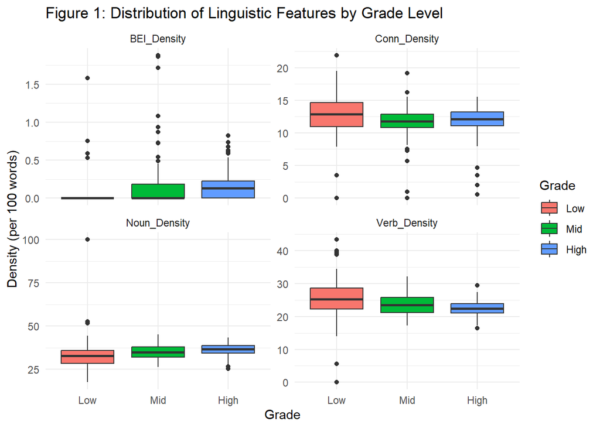

```r
# Reshape data for plotting
data_long <- data %>%
  pivot_longer(cols = ends_with("Density"), names_to = "Feature", values_to = "Density")

ggplot(data_long, aes(x = Grade, y = Density, fill = Grade)) +
  geom_boxplot() +
  facet_wrap(~Feature, scales = "free_y") +
  theme_minimal() +
  labs(title = "Figure 1: Distribution of Linguistic Features by Grade Level",
       y = "Density (per 100 words)")
```

# 3. Study 1: One-way ANOVA Analysis

In this section, we apply One-way ANOVA, the standard method for comparing means across three groups.

## 3.1 ANOVA Results

We test the hypothesis that the mean density of each feature differs across grade levels.

```r
# Function to perform ANOVA and print results
run_anova <- function(var_name, data) {
  formula <- as.formula(paste(var_name, "~ Grade"))
  model <- aov(formula, data = data)
  print(paste("=== ANOVA Results for:", var_name, "==="))
  print(summary(model))

  # Post-hoc Tukey test
  print(TukeyHSD(model))
}

# Run ANOVA for all four features
run_anova("Noun_Density", data)
```

```
## [1] "=== ANOVA Results for: Noun_Density ==="
##              Df Sum Sq Mean Sq F value   Pr(>F)
## Grade         2    617  308.71   8.723 0.000203 ***
## Residuals   335  11856   35.39
## ---
## Signif. codes:  0 '***' 0.001 '**' 0.01 '*' 0.05 '.' 0.1 ' ' 1
##   Tukey multiple comparisons of means
##     95% family-wise confidence level
##
## Fit: aov(formula = formula, data = data)
##
## $Grade
##              diff        lwr      upr     p adj
## Mid-Low  2.031237  0.1597463 3.902728 0.0296766
## High-Low 3.349667  1.4513176 5.248016 0.0001227
## High-Mid 1.318430 -0.5173893 3.154249 0.2102353
```

```r
run_anova("Verb_Density", data)
```

```
## [1] "=== ANOVA Results for: Verb_Density ==="
##              Df Sum Sq Mean Sq F value   Pr(>F)
## Grade         2    503  251.33   14.76 7.18e-07 ***
## Residuals   335   5704   17.03
## ---
## Signif. codes:  0 '***' 0.001 '**' 0.01 '*' 0.05 '.' 0.1 ' ' 1
##   Tukey multiple comparisons of means
##     95% family-wise confidence level
##
## Fit: aov(formula = formula, data = data)
##
## $Grade
##                diff       lwr        upr     p adj
## Mid-Low  -2.0609020 -3.358976 -0.7628283 0.0006380
## High-Low -2.9754421 -4.292145 -1.6587394 0.0000006
## High-Mid -0.9145402 -2.187872  0.3587913 0.2101842
```

```r
run_anova("Connective_Density", data = data %>% rename(Connective_Density = Conn_Density))
```

```
## [1] "=== ANOVA Results for: Connective_Density ==="
##              Df Sum Sq Mean Sq F value  Pr(>F)
## Grade         2   84.3   42.16   6.465 0.00176 **
## Residuals   335 2184.6    6.52
## ---
## Signif. codes:  0 '***' 0.001 '**' 0.01 '*' 0.05 '.' 0.1 ' ' 1
##   Tukey multiple comparisons of means
##     95% family-wise confidence level
##
## Fit: aov(formula = formula, data = data)
##
## $Grade
##                diff        lwr        upr     p adj
## Mid-Low  -1.1802739 -1.9836251 -0.3769226 0.0017700
## High-Low -0.9190634 -1.7339438 -0.1041831 0.0225568
## High-Mid  0.2612105 -0.5268283  1.0492492 0.7153716
```

```r
run_anova("BEI_Density", data)
```

```
## [1] "=== ANOVA Results for: BEI_Density ==="
##              Df Sum Sq Mean Sq F value   Pr(>F)
## Grade         2  1.121  0.5605    8.32 0.000298 ***
## Residuals   335 22.569  0.0674
## ---
## Signif. codes:  0 '***' 0.001 '**' 0.01 '*' 0.05 '.' 0.1 ' ' 1
##   Tukey multiple comparisons of means
##     95% family-wise confidence level
##
## Fit: aov(formula = formula, data = data)
##
## $Grade
##                 diff         lwr        upr     p adj
## Mid-Low  0.122502293  0.04084718 0.20415741 0.0013637
## High-Low 0.126420321  0.04359335 0.20924729 0.0010914
## High-Mid 0.003918028 -0.07618068 0.08401674 0.9927161
```

**One-way ANOVA Results:** The ANOVA results revealed significant main effects of Grade Level on all four linguistic features $(p < .01)$. Post-hoc Tukey HSD tests indicated a consistent pattern where Low-grade texts significantly differed from Mid- and High-grade texts, while no significant differences were found between Mid and High grades across all features.

### 3.1.1 Noun Density

- **Overall Test (ANOVA):** The analysis showed a significant effect of grade level on noun density $(F(2, 335) = 8.723,$ $p < .001)$. This indicates that noun usage differs significantly among at least one of the grade groups.
- **Post-hoc Comparisons (Tukey HSD):**
  - **Mid vs. Low:** The difference is significant $(p < .05)$, with Mid-grade texts having a higher noun density (diff = 2.03).
  - **High vs. Low:** The difference is highly significant $(p < .001)$, with High-grade texts showing a greater noun density (diff = 3.35).
  - **High vs. Mid:** No significant difference was found $(p > .05)$, diff = 1.31).
- **Interpretation:** Noun density increases with grade level. This aligns with the linguistic tendency toward **nominalization** in academic texts. As grade levels progress, reading materials shift from narrative styles (storytelling) to expository texts, which require a higher density of nouns to convey abstract concepts and information.

### 3.1.2 Verb Density

- **Overall Test (ANOVA):** A highly significant main effect was found for verb density $(F(2, 335) = 14.76,$ $p < .001)$.
- **Post-hoc Comparisons (Tukey HSD):**
  - **Mid vs. Low:** Significant difference $(p < .001)$, with Mid-grade texts having lower verb density (diff = -2.06).
  - **High vs. Low:** Significant difference $(p < .001)$, with High-grade texts having lower verb density (diff = -2.97).
  - **High vs. Mid:** No significant difference was found $(p > .05$, $diff = -0.91)$.
- **Interpretation:** Verb density decreases as grade level increases (Low > Mid > High). Lower-grade texts often feature simple action descriptions (e.g., *他跑了*, *他笑了*), resulting in a high proportion of verbs. In contrast, higher-grade texts employ longer sentences with more adjectives, modifiers, and noun clauses, which “dilutes” the density of verbs relative to the total word count.

### 3.1.3 Connective Density

- **Overall Test (ANOVA):** The ANOVA revealed a significant difference in connective density across grades $(F(2, 335) = 6.465,$ $p < .01)$.
- **Post-hoc Comparisons (Tukey HSD):**
  - **Mid vs. Low:** Significant difference $(p < .01)$, with Mid-grade texts showing lower density (diff = -1.18).
  - **High vs. Low:** Significant difference $(p < .05)$, with High-grade texts showing lower density (diff = -0.92).
  - **High vs. Mid:** No significant difference was found $(p > .05)$.
- **Interpretation:** Connective density is highest in Low-grade texts and decreases in Mid- and High-grade texts. While counterintuitive—given that advanced texts are usually more syntactically complex—this may reflect the frequent use of explicit, simple sequential markers (e.g., *然後*, *於是*) in early literacy materials. Higher-grade texts may utilize more concise syntactic structures (e.g., Serial Verb Constructions, relative clauses) to replace explicit connectives, or the decrease in density may simply result from longer sentence lengths increasing the denominator.

### 3.1.4 *BEI*-construction Density

- **Overall Test (ANOVA):** There was a significant main effect of grade level on the density of *BEI*-constructions $(F(2, 335) = 8.32,$ $p < .001)$.
- **Post-hoc Comparisons (Tukey HSD):**
  - **Mid vs. Low:** Significant difference $(p < .01)$, with Mid-grade texts showing higher usage (diff = 0.12).
  - **High vs. Low:** Significant difference $(p < .01)$, with High-grade texts showing higher usage (diff = 0.12).
  - **High vs. Mid:** The difference was minimal and not significant $(p > .05)$.
- **Interpretation:** The density of *BEI*-constructions increases with grade level. As a complex syntactic structure often carrying semantic nuances of disposal or adversity, the *BEI*-construction is rarely found in Low-grade texts (approaching zero) and begins to appear significantly only in Mid- and High-grade texts.

## 3.2 Limitations of ANOVA

While ANOVA provides a useful baseline, it relies on the assumption of normality and usually requires homogeneity of variance. Furthermore, analyzing density (ratios) can be problematic when the denominator (text length) varies significantly (Low: 111 vs. High: 602). The “BEI-construction” data is also heavily skewed (many zeros), violating normality assumptions. Therefore, while these findings are logically sound, the statistical validity is less robust compared to the subsequent Poisson model analysis.

To illustrate why ANOVA might be insufficient, we visualized the distribution of our data.

### 3.2.1 Variation in Text Length

The reliability of density metrics depends on stable denominators. However, Figure 2 shows a significant disparity in text length between Low and High grades, introducing potential bias in ratio-based comparisons.

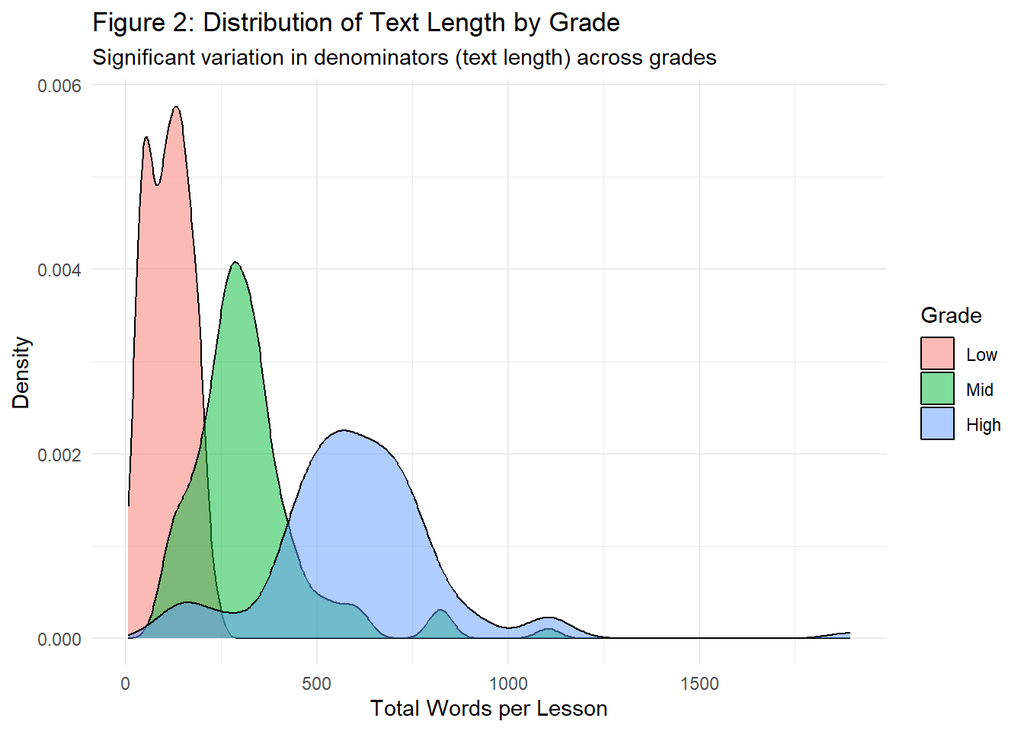

```r
ggplot(data, aes(x = Total_Words, fill = Grade)) +
  geom_density(alpha = 0.5) +
  labs(title = "Figure 2: Distribution of Text Length by Grade",
       subtitle = "Significant variation in denominators (text length) across grades",
       x = "Total Words per Lesson",
       y = "Density") +
  theme_minimal()
```

### 3.2.2 Zero-Inflation in BEI Constructions

The normality assumption of ANOVA is severely violated by the BEI-construction data. As shown below, the distribution is heavily zero-inflated and right-skewed.

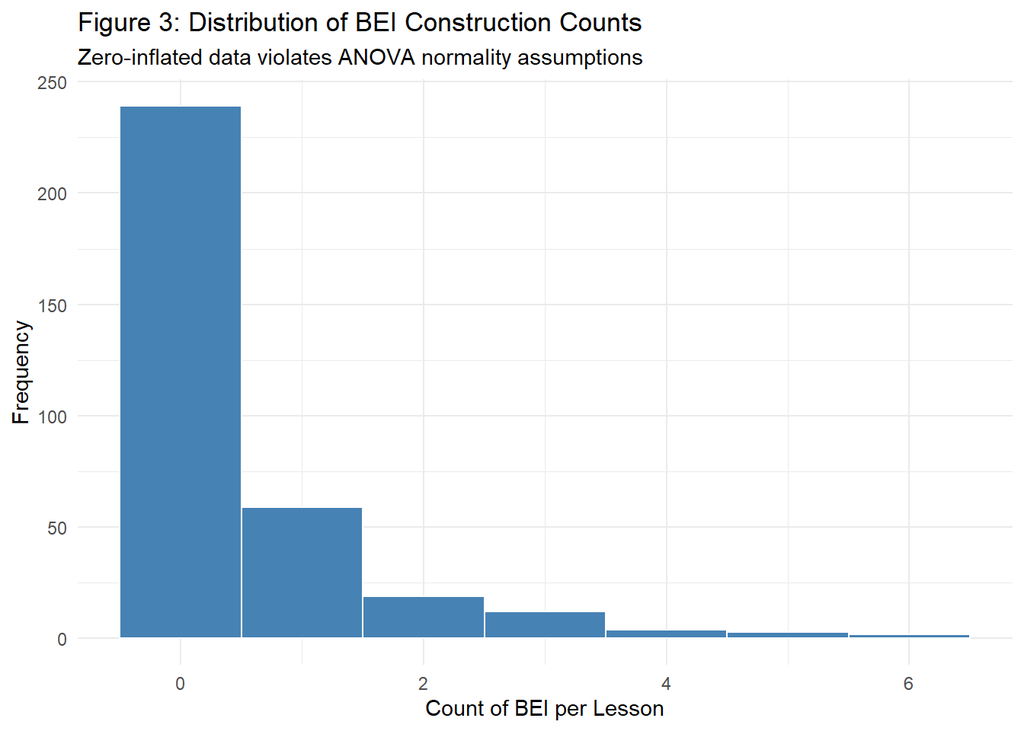

```r
ggplot(data, aes(x = BEI_Count)) +
  geom_histogram(binwidth = 1, fill = "steelblue", color = "white") +
  labs(title = "Figure 3: Distribution of BEI Construction Counts",
       subtitle = "Zero-inflated data violates ANOVA normality assumptions",
       x = "Count of BEI per Lesson",
       y = "Frequency") +
  theme_minimal()
```

# 4. Study 2: Generalized Linear Model (GLM)

To address the limitations of ANOVA, we adopt a Generalized Linear Model (GLM) approach. We treat the data as Counts (Poisson distribution) and use log(Total_Words) as an offset to control for text length.

## 4.1 Poisson Regression Results

We first fit a Poisson model for each linguistic feature.

```r
# Function to run Poisson GLM and output estimated marginal means
run_poisson <- function(count_var, data) {
  formula_str <- paste(count_var, "~ Grade + offset(log(Total_Words))")

  # Fit Model
  model <- glm(as.formula(formula_str), family = poisson, data = data)

  # Print Summary
  print(paste(">>> GLM (Poisson) Results for:", count_var))
  print(summary(model))

  # Estimated Marginal Means (Back-transformed to Rate)
  emm <- emmeans(model, ~ Grade, type = "response")
  print(emm)

  # Pairwise comparisons
  print(pairs(emm, adjust = "tukey"))
}

# Run Poisson for all features
run_poisson("Noun_Count", data)
```

```
## [1] ">>> GLM (Poisson) Results for: Noun_Count"
##
## Call:
## glm(formula = as.formula(formula_str), family = poisson, data = data)
##
## Coefficients:
##             Estimate Std. Error z value Pr(>|z|)
## (Intercept) -1.12058    0.01623 -69.050  < 2e-16 ***
## GradeMid     0.08599    0.01836   4.684 2.81e-06 ***
## GradeHigh    0.11144    0.01743   6.395 1.60e-10 ***
## ---
## Signif. codes:  0 '***' 0.001 '**' 0.01 '*' 0.05 '.' 0.1 ' ' 1
##
## (Dispersion parameter for poisson family taken to be 1)
##
##     Null deviance: 538.75  on 337  degrees of freedom
## Residual deviance: 495.82  on 335  degrees of freedom
## AIC: 2634
##
## Number of Fisher Scoring iterations: 4
##
##  Grade rate    SE  df asymp.LCL asymp.UCL
##  Low    114 1.850 Inf       110       117
##  Mid    124 1.060 Inf       122       126
##  High   127 0.807 Inf       126       129
##
## Confidence level used: 0.95
## Intervals are back-transformed from the log scale
##  contrast   ratio     SE  df null z.ratio p.value
##  Low / Mid  0.918 0.0168 Inf    1  -4.684  <.0001
##  Low / High 0.895 0.0156 Inf    1  -6.395  <.0001
##  Mid / High 0.975 0.0104 Inf    1  -2.384  0.0451
##
## P value adjustment: tukey method for comparing a family of 3 estimates
## Tests are performed on the log scale
```

```r
run_poisson("Verb_Count", data)
```

```
## [1] ">>> GLM (Poisson) Results for: Verb_Count"
##
## Call:
## glm(formula = as.formula(formula_str), family = poisson, data = data)
##
## Coefficients:
##             Estimate Std. Error z value Pr(>|z|)
## (Intercept) -1.38013    0.01848 -74.693  < 2e-16 ***
## GradeMid    -0.09104    0.02134  -4.266 1.99e-05 ***
## GradeHigh   -0.11451    0.02017  -5.677 1.37e-08 ***
## ---
## Signif. codes:  0 '***' 0.001 '**' 0.01 '*' 0.05 '.' 0.1 ' ' 1
##
## (Dispersion parameter for poisson family taken to be 1)
##
##     Null deviance: 408.0  on 337  degrees of freedom
## Residual deviance: 376.4  on 335  degrees of freedom
## AIC: 2383.1
##
## Number of Fisher Scoring iterations: 4
##
##  Grade rate    SE  df asymp.LCL asymp.UCL
##  Low   87.8 1.620 Inf      84.6      91.0
##  Mid   80.1 0.855 Inf      78.5      81.8
##  High  78.3 0.633 Inf      77.0      79.5
##
## Confidence level used: 0.95
## Intervals are back-transformed from the log scale
##  contrast   ratio     SE  df null z.ratio p.value
##  Low / Mid   1.10 0.0234 Inf    1   4.266  0.0001
##  Low / High  1.12 0.0226 Inf    1   5.677  <.0001
##  Mid / High  1.02 0.0137 Inf    1   1.752  0.1862
##
## P value adjustment: tukey method for comparing a family of 3 estimates
## Tests are performed on the log scale
```

```r
run_poisson("Conn_Count", data)
```

```
## [1] ">>> GLM (Poisson) Results for: Conn_Count"
##
## Call:
## glm(formula = as.formula(formula_str), family = poisson, data = data)
##
## Coefficients:
##             Estimate Std. Error z value Pr(>|z|)
## (Intercept) -2.06207    0.02598 -79.356   <2e-16 ***
## GradeMid    -0.07039    0.02993  -2.352   0.0187 *
## GradeHigh   -0.04648    0.02822  -1.647   0.0995 .
## ---
## Signif. codes:  0 '***' 0.001 '**' 0.01 '*' 0.05 '.' 0.1 ' ' 1
##
## (Dispersion parameter for poisson family taken to be 1)
##
##     Null deviance: 389.74  on 337  degrees of freedom
## Residual deviance: 384.10  on 335  degrees of freedom
## AIC: 2155.7
##
## Number of Fisher Scoring iterations: 4
##
##  Grade rate    SE  df asymp.LCL asymp.UCL
##  Low   44.4 1.150 Inf      42.2      46.7
##  Mid   41.4 0.615 Inf      40.2      42.6
##  High  42.4 0.466 Inf      41.5      43.3
##
## Confidence level used: 0.95
## Intervals are back-transformed from the log scale
##  contrast   ratio     SE  df null z.ratio p.value
##  Low / Mid  1.073 0.0321 Inf    1   2.352  0.0490
##  Low / High 1.048 0.0296 Inf    1   1.647  0.2259
##  Mid / High 0.976 0.0181 Inf    1  -1.293  0.3989
##
## P value adjustment: tukey method for comparing a family of 3 estimates
## Tests are performed on the log scale
```

```r
run_poisson("BEI_Count", data)
```

```
## [1] ">>> GLM (Poisson) Results for: BEI_Count"
##
## Call:
## glm(formula = as.formula(formula_str), family = poisson, data = data)
##
## Coefficients:
##             Estimate Std. Error z value Pr(>|z|)
## (Intercept)  -7.5708     0.4082 -18.545  < 2e-16 ***
## GradeMid      1.0454     0.4296   2.434  0.01495 *
## GradeHigh     1.1788     0.4189   2.814  0.00489 **
## ---
## Signif. codes:  0 '***' 0.001 '**' 0.01 '*' 0.05 '.' 0.1 ' ' 1
##
## (Dispersion parameter for poisson family taken to be 1)
##
##     Null deviance: 362.32  on 337  degrees of freedom
## Residual deviance: 350.85  on 335  degrees of freedom
## AIC: 591.23
##
## Number of Fisher Scoring iterations: 6
##
##  Grade  rate     SE  df asymp.LCL asymp.UCL
##  Low   0.180 0.0734 Inf    0.0808     0.400
##  Mid   0.511 0.0683 Inf    0.3935     0.664
##  High  0.584 0.0547 Inf    0.4863     0.702
##
## Confidence level used: 0.95
## Intervals are back-transformed from the log scale
##  contrast   ratio    SE  df null z.ratio p.value
##  Low / Mid  0.352 0.151 Inf    1  -2.434  0.0397
##  Low / High 0.308 0.129 Inf    1  -2.814  0.0136
##  Mid / High 0.875 0.143 Inf    1  -0.817  0.6924
##
## P value adjustment: tukey method for comparing a family of 3 estimates
## Tests are performed on the log scale
```

### 4.1.1 Noun Count

- **Model Fit:** The predictors significantly explain the variance in noun counts.
- **Coefficients & Trends:** There is a clear upward trend. Compared to the Low grade (intercept), both Mid $(z = 4.68,$ $p < .001)$ and High $(z = 6.40,$ $p < .001)$ grades show significantly positive coefficients.
- **Pairwise Comparisons (Tukey):**
  - **Low vs. Mid:** Significant $(p < .0001)$. The rate ratio (Low/Mid) is 0.918, indicating Noun frequency in Low grade is lower than in Mid grade.
  - **Low vs. High:** Significant $(p < .0001)$. The ratio is 0.895, showing the largest difference.
  - **Mid vs. High:** Significant $(p = .0451)$. High grade texts have a slightly but significantly higher noun rate than Mid grade texts (Ratio = 0.975).
- **Interpretation:** Different from the ANOVA results, the Poisson model suggests that noun usage significantly increases at every stage of grade progression, reflecting a continuous increase in information density.

### 4.1.2 Verb Count

- **Coefficients & Trends:** The trend is downward. Mid $(z = -4.27,$ $p < .001)$ and High $(z = -5.68,$ $p < .001)$ grades have negative coefficients compared to the Low grade.
- **Pairwise Comparisons (Tukey):**
  - **Low vs. Mid:** Significant $(p = .0001)$. Low grade verb rate is approximately 1.10 times that of the Mid grade.
  - **Low vs. High:** Significant $(p < .0001)$. Low grade verb rate is 1.12 times that of the High grade.
  - **Mid vs. High:** Not significant $(p = .1862)$.
- **Interpretation:** Verb density drops significantly after the Low grade (Grades 1-2) and then stabilizes. This suggests a transition from action-heavy narratives in early grades to more descriptive styles in later grades, where verbs are not further reduced significantly between Mid and High levels.

### 4.1.3 Connective Count

- **Coefficients & Trends:** Mid grade shows a significant negative coefficient $(z = -2.35,$ $p = .0187)$, while High grade does not differ significantly from Low grade in the model summary $(p = .0995)$.
- **Pairwise Comparisons (Tukey):**
  - **Low vs. Mid:** Significant $(p = .0490)$. The rate in Low grade is roughly 1.07 times higher than in Mid grade.
  - **Low vs. High:** Not significant $(p = .2259)$.
  - **Mid vs. High:** Not significant $(p = .3989)$.
- **Interpretation:** The Poisson model suggests a subtler pattern than ANOVA. While Low grade texts still show the highest usage of connectives, the only statistically significant drop occurs between **Low and Mid** grades. The difference between Low and High grades is not statistically significant in this count-based model, suggesting the variance in high-grade texts might be larger than assumed in ANOVA.

### 4.1.4 *BEI*-construction Count

- **Coefficients & Trends:** A sharp increase is observed. Both Mid $(z = 2.43,$ $p < .05)$ and High $(z = 2.81,$ $p < .01)$ grades show significant positive coefficients compared to the baseline.
- **Pairwise Comparisons (Tukey):**
  - **Low vs. Mid:** Significant $(p = .0397)$. The rate ratio (Low/Mid) is 0.352, meaning the occurrence of *Bei* in Low grade is only about 35% of that in Mid grade.
  - **Low vs. High:** Significant $(p = .0136)$. The ratio is 0.308, indicating a threefold increase from Low to High grade.
  - **Mid vs. High:** Not significant $(p = .6924)$.
- **Interpretation:** The Poisson model confirms that *BEI*-constructions are a late-acquired feature. There is a dramatic jump in usage from Low to Mid grade, after which the frequency stabilizes. This model handles the low-frequency nature of *BEI* constructions robustly, highlighting the magnitude of the developmental leap (approx. 3x increase).

## 4.2 Visualizing Poisson Results

To intuitively understand the developmental trends modeled by Poisson, we visualized the **Estimated Marginal Means (EMMs)**. These plots show the predicted frequency of each linguistic feature across grades, holding the text length constant at the overall average (349 words).

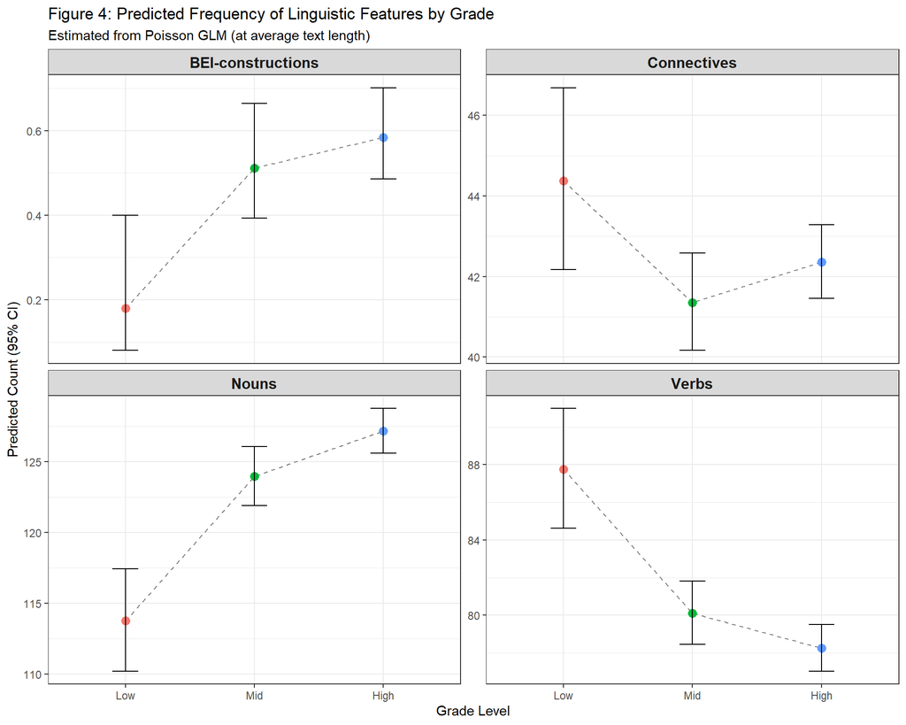

```r
# Fit Poisson models
model_pois_noun <- glm(Noun_Count ~ Grade + offset(log(Total_Words)),
                       family = poisson, data = data)

model_pois_verb <- glm(Verb_Count ~ Grade + offset(log(Total_Words)),
                       family = poisson, data = data)

model_pois_conn <- glm(Conn_Count ~ Grade + offset(log(Total_Words)),
                       family = poisson, data = data)

model_pois_BEI <- glm(BEI_Count ~ Grade + offset(log(Total_Words)),
                       family = poisson, data = data)

# Helper function to extract EMMs from a model
get_emm_data <- function(model, feature_name) {
  # Calculate EMMs
  emm <- emmeans(model, ~ Grade, type = "response")

  # Convert to data frame
  emm_df <- as.data.frame(emm)
  emm_df$Feature <- feature_name
  return(emm_df)
}

# Extract data from all 4 models
plot_data <- rbind(
  get_emm_data(model_pois_noun, "Nouns"),
  get_emm_data(model_pois_verb, "Verbs"),
  get_emm_data(model_pois_conn, "Connectives"),
  get_emm_data(model_pois_BEI,  "BEI-constructions")
)

# Create the Plot
ggplot(plot_data, aes(x = Grade, y = rate, group = 1)) +
  # Draw the line and points
  geom_line(color = "gray50", linetype = "dashed") +
  geom_point(size = 3, aes(color = Grade)) +

  # Add Error Bars (Confidence Intervals)
  geom_errorbar(aes(ymin = asymp.LCL, ymax = asymp.UCL), width = 0.2) +

  # Facet by Feature
  facet_wrap(~Feature, scales = "free_y") +

  # Aesthetics
  theme_bw() +
  labs(title = "Figure 4: Predicted Frequency of Linguistic Features by Grade",
       subtitle = "Estimated from Poisson GLM (at average text length)",
       y = "Predicted Count (95% CI)",
       x = "Grade Level") +
  theme(legend.position = "none",
        strip.text = element_text(size = 12, face = "bold"))
```

## 4.3 Issue of Overdispersion

A critical assumption of Poisson is that Mean = Variance. We test this using `dispersiontest`.

```r
# Fit Poisson models
model_pois_noun <- glm(Noun_Count ~ Grade + offset(log(Total_Words)),
                       family = poisson, data = data)

model_pois_verb <- glm(Verb_Count ~ Grade + offset(log(Total_Words)),
                       family = poisson, data = data)

model_pois_conn <- glm(Conn_Count ~ Grade + offset(log(Total_Words)),
                       family = poisson, data = data)

model_pois_BEI <- glm(BEI_Count ~ Grade + offset(log(Total_Words)),
                       family = poisson, data = data)


# Check for Overdispersion
dp_noun <- dispersiontest(model_pois_noun)
print(dp_noun)
```

```
##
##  Overdispersion test
##
## data:  model_pois_noun
## z = 4.1483, p-value = 1.675e-05
## alternative hypothesis: true dispersion is greater than 1
## sample estimates:
## dispersion
##   1.461509
```

```r
dp_verb <- dispersiontest(model_pois_verb)
print(dp_verb)
```

```
##
##  Overdispersion test
##
## data:  model_pois_verb
## z = 1.1779, p-value = 0.1194
## alternative hypothesis: true dispersion is greater than 1
## sample estimates:
## dispersion
##   1.092085
```

```r
dp_conn <- dispersiontest(model_pois_conn)
print(dp_conn)
```

```
##
##  Overdispersion test
##
## data:  model_pois_conn
## z = 0.040552, p-value = 0.4838
## alternative hypothesis: true dispersion is greater than 1
## sample estimates:
## dispersion
##   1.004945
```

```r
dp_BEI <- dispersiontest(model_pois_BEI)
print(dp_BEI)
```

```
##
##  Overdispersion test
##
## data:  model_pois_BEI
## z = 2.7479, p-value = 0.002999
## alternative hypothesis: true dispersion is greater than 1
## sample estimates:
## dispersion
##   1.659606
```

- **Nouns**: $z = 4.15, p < .001$ (Dispersion = 1.46) $\rightarrow$ **Significant Overdispersion**
- **Verbs**: $z = 1.18, p = .119$ (Dispersion = 1.09) $\rightarrow$ No Significant Overdispersion
- **Connectives**: $z = 0.04, p = .484$ (Dispersion = 1.00) $\rightarrow$ No Significant Overdispersion
- **BEI-constructions**: $z = 2.75, p < .01$ (Dispersion = 1.66) $\rightarrow$ **Significant Overdispersion**

**Methodological Decision:** The diagnostics indicate that while *Verb* and *Connective* counts align well with the Poisson distribution, *Noun* and *BEI-construction* counts exhibit significant overdispersion (Variance > Mean). Using a standard Poisson model for overdispersed data would lead to underestimated standard errors and inflated Type I error (false positives) rates.

# 5. Conclusion and Future Work

Methodologically, this study contrasts two statistical approaches. While **One-way ANOVA** provided a quick and intuitive overview of feature density, the **Poisson GLM** offered a theoretically more appropriate framework by explicitly modeling the count nature of the linguistic data and controlling for text length via offsets.

However, diagnostic tests revealed significant **overdispersion** in certain features (e.g., Nouns and *BEI*-constructions), suggesting that the standard Poisson model may still underestimate standard errors. Future research should therefore explore **Negative Binomial Regression** to specifically address this dispersion issue, and employ **Mixed-effects Models (LMM)** to account for potential random effects, such as stylistic variations among different publishers.